# Which TV Shows are Risers and Fallers?

Ted Laderas

11/4/2019

# Which TV shows are Risers or Fallers?

This dataset comes from Tidy Tuesday: https://github.com/rfordatascience/tidytuesday/blob/master/data/2019/2019-01-08

I want to find those shows that have risen in ratings (positive trend) versus those whow have fallen in ratings (negative trend).

A quick and dirty way to find this is to fit a linear model for each of the TV shows. We’re modeling `av_rating ~ seasonNumber` using the `lm()` function and extracting the `seasonNumber` coefficient, which will give us the slope for each TV show. The slope will be our measure of trend.

```r
#fit a linear model to each show
#we'll filter out those shows that have 3 seasons or less later
fits <- tv_data %>% group_by(title) %>% do(fit = lm(av_rating ~ seasonNumber, data = .))

#extract the coefficients
coefs <- tidy(fits, fit)
#extract the slopes
slopes <- coefs %>% filter(term == "seasonNumber")
```

Now we have the slopes, let’s view a histogram of the slopes. The distribution is approximately normal, with most shows gathered in the middle (showing little to no change in ratings across the seasons).

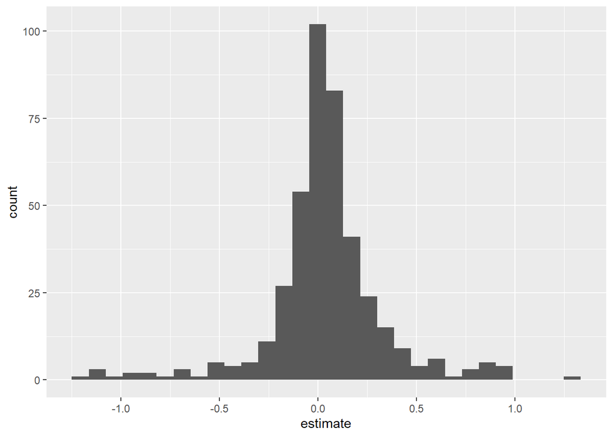

```r
slopes %>% ggplot(aes(x=estimate)) + geom_histogram()
```

# Filtering the data

As a quick data cleaning, let’s count the number of seasons per show using `n()`.

```r
season_count <- tv_data %>% group_by(title) %>% summarize(count = n())
```

Let’s merge this with our `slopes`, so we can filter by number of seasons:

```r
slopes <- slopes %>%
  inner_join(y=season_count, by=c("title")) %>%
  filter(count > 3)

head(slopes)
```

```
## # A tibble: 6 x 7
## # Groups:   title [6]
##   title               term       estimate std.error statistic p.value count
##   <chr>               <chr>         <dbl>     <dbl>     <dbl>   <dbl> <int>
## 1 12 Monkeys          seasonNum~   0.260     0.0609     4.28   0.0505     4
## 2 24                  seasonNum~  -0.0304    0.0207    -1.47   0.191      8
## 3 90210               seasonNum~   0.0325    0.130      0.251  0.818      5
## 4 Agatha Christie's ~ seasonNum~   0.0240    0.0276     0.868  0.434      6
## 5 Agents of S.H.I.E.~ seasonNum~   0.159     0.0429     3.70   0.0344     5
## 6 Alias               seasonNum~  -0.0250    0.0938    -0.267  0.807      5
```

Let’s look at the histogram after we filter by number of seasons. We can see that overall, filtering reduces the magnitude of the slopes, indicating that a lot of the outliers were driven by shows with 3 seasons or less.

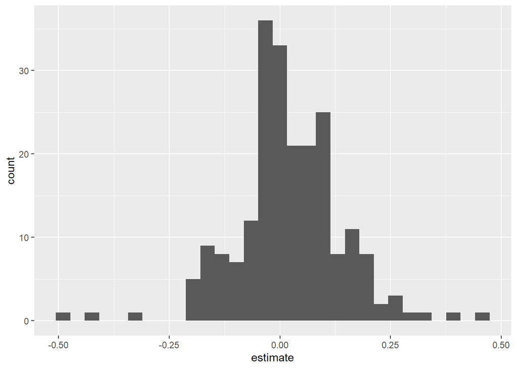

```r
slopes %>% ggplot(aes(x=estimate)) + geom_histogram()
```

Based on the above histogram, we want to select those shows that are *risers* (whose overall trajectory increases), and *fallers* - those whose rating decreases over time.

We select the following criteria for *risers*: a slope increase of 0.2 and above. For *fallers*, we select a slope decrease of -0.15 or lower. We also include “Law & Order” for comparison.

```r
risers_fallers <- slopes %>%
  filter(estimate > 0.2 |
           estimate < -0.15 |
           title == "Law & Order") %>%
  mutate(status = ifelse(estimate >= 0, "riser", "faller")) %>%
  select(title, status, slope = estimate)

#removing seasons 11 and up - (Law and Order has 20 seasons!)
small_data <- tv_data %>% inner_join(y=risers_fallers, by=c("title")) %>% filter(seasonNumber < 11)

#select a subset of variables
small_data <- small_data %>% select(title, seasonNumber, av_rating, share, genres, status)

DT::datatable(small_data)
```

|  | title | seasonNumber | av_rating | share | genres | status |
| --- | --- | --- | --- | --- | --- | --- |
| 1 | 12 Monkeys | 1 | 8.3407 | 0.46 | Adventure,Drama,Mystery | riser |
| 2 | 12 Monkeys | 2 | 8.8196 | 0.25 | Adventure,Drama,Mystery | riser |
| 3 | 12 Monkeys | 3 | 9.0369 | 0.19 | Adventure,Drama,Mystery | riser |
| 4 | 12 Monkeys | 4 | 9.1363 | 0.38 | Adventure,Drama,Mystery | riser |
| 5 | Are You Afraid of the Dark? | 1 | 9.1736 | 8.27 | Drama,Family,Fantasy | faller |
| 6 | Are You Afraid of the Dark? | 2 | 9.235 | 6.98 | Drama,Family,Fantasy | faller |
| 7 | Are You Afraid of the Dark? | 3 | 9.4349 | 2.6 | Drama,Family,Fantasy | faller |
| 8 | Are You Afraid of the Dark? | 4 | 9.3097 | 2.15 | Drama,Family,Fantasy | faller |
| 9 | Are You Afraid of the Dark? | 5 | 8.9533 | 2.31 | Drama,Family,Fantasy | faller |
| 10 | Are You Afraid of the Dark? | 6 | 6.0237 | 0.93 | Drama,Family,Fantasy | faller |

[output cut: 152 more lines]

A few too many shows for our exercise. Let’s limit the shows by filtering some more.

```r
#select only a subset of shows
small_data <- small_data %>% filter(title %in% c("BoJack Horseman", "Breaking Bad", "Roseanne", "Law & Order", "Pretty Little Liars", "The Walking Dead", "Nashville"))

write.csv(small_data, here::here("data/tv_shows.csv"))
```

## The plot to simplify

Here’s the plot we’ll want to simplify in the exercise.

```r
pl <- small_data %>% ggplot(aes(x=seasonNumber, y=av_rating, color = title, group=title)) + geom_line()

plotly::ggplotly(pl)
```

[interactive chart not shown]

Here’s a plot colored by `riser` or `faller` status:

```r
pl <- small_data %>% ggplot(aes(x=seasonNumber, y=av_rating, color = status, group=title)) + geom_line()

plotly::ggplotly(pl)
```

[interactive chart not shown]

# Looking at risers/fallers by share

Another way to visualize this dataset is by audience share. Here we see that `risers` don’t necessarily have a big audience, except for `Breaking Bad`:

```r
pl <- small_data %>% ggplot(aes(x=seasonNumber, y=share, color = status, group=title)) + geom_line()

plotly::ggplotly(pl)
```

[interactive chart not shown]